# Bellabeat

Lucky Gbelode

2022-09-29

### TABLE OF CONTENTS

1.0 INTRODUCTION  
1.1 LOADING THE REQUIRED LIBRARIES  
1.2 LOADING THE DATASETS  
1.3 DATASETS BASIC STATISTICS

2.0 DATA WRANGLING  
2.1 CLEANING THE SLEEP TABLE  
2.2 CLEANING THE DAILY TABLE

3.0 ANALYSIS  
3.1 DAILY STATISTICS OF USERS  
3.2 SLEEP STATISTICS OF USERS  
3.3 USERS SLEEP PATTERN  
3.4 USERS ACTIVE AND SEDENTARY MINUTES  
3.5 USERS STEPS  
3.6 USERS DAILY STATISTICS TRENDS  
3.7 USERS STATISTICS ON DIFFERENT DAYS  
3.8 USERS METRICS ON WEEKENDS AND WEEK DAYS  
3.9 USERS PERFORMANCE

### 1.0 INTRODUCTION

Bellalbeat is a high-tech company that manufactures smart health products.They manufacture smart devices that monitor users daily activities, steps, calories and sleep .The data used in this analysis are from FitBit users personal fitness tracker available on Kaggle. This study will conduct an analysis on how consumers uses its smart devices, in order to gain valuable insights that will inform business decisions and marketing strategies.

#### 1.1 LOADING THE REQUIRED LIBRARIES

```r
  library(tidyverse)
  library(lubridate )
  library(ggplot2)
  library(DT)
  library(prettydoc)
  library(kableExtra)
```

#### 1.2 LOADING THE DATASETS

```r
  daily <- read_csv("dailyActivity_merged.csv")
  sleep <- read_csv("sleepDay_merged.csv")
```

- The dailyActivity_merged and sleepDay_merged tables will be used in this analysis.

#### 1.3 DATASETS DESCRIPTIVE STATISTICS

```r
  str(daily)
```

```
## spec_tbl_df [940 × 15] (S3: spec_tbl_df/tbl_df/tbl/data.frame)
##  $ Id                      : num [1:940] 1.5e+09 1.5e+09 1.5e+09 1.5e+09 1.5e+09 ...
##  $ ActivityDate            : chr [1:940] "4/12/2016" "4/13/2016" "4/14/2016" "4/15/2016" ...
##  $ TotalSteps              : num [1:940] 13162 10735 10460 9762 12669 ...
##  $ TotalDistance           : num [1:940] 8.5 6.97 6.74 6.28 8.16 ...
##  $ TrackerDistance         : num [1:940] 8.5 6.97 6.74 6.28 8.16 ...
##  $ LoggedActivitiesDistance: num [1:940] 0 0 0 0 0 0 0 0 0 0 ...
##  $ VeryActiveDistance      : num [1:940] 1.88 1.57 2.44 2.14 2.71 ...
##  $ ModeratelyActiveDistance: num [1:940] 0.55 0.69 0.4 1.26 0.41 ...
##  $ LightActiveDistance     : num [1:940] 6.06 4.71 3.91 2.83 5.04 ...
##  $ SedentaryActiveDistance : num [1:940] 0 0 0 0 0 0 0 0 0 0 ...
##  $ VeryActiveMinutes       : num [1:940] 25 21 30 29 36 38 42 50 28 19 ...
##  $ FairlyActiveMinutes     : num [1:940] 13 19 11 34 10 20 16 31 12 8 ...
##  $ LightlyActiveMinutes    : num [1:940] 328 217 181 209 221 164 233 264 205 211 ...
##  $ SedentaryMinutes        : num [1:940] 728 776 1218 726 773 ...
##  $ Calories                : num [1:940] 1985 1797 1776 1745 1863 ...
##  - attr(*, "spec")=
##   .. cols(
##   ..   Id = col_double(),
##   ..   ActivityDate = col_character(),
##   ..   TotalSteps = col_double(),
##   ..   TotalDistance = col_double(),
##   ..   TrackerDistance = col_double(),
##   ..   LoggedActivitiesDistance = col_double(),
##   ..   VeryActiveDistance = col_double(),
##   ..   ModeratelyActiveDistance = col_double(),
##   ..   LightActiveDistance = col_double(),
##   ..   SedentaryActiveDistance = col_double(),
##   ..   VeryActiveMinutes = col_double(),
##   ..   FairlyActiveMinutes = col_double(),
##   ..   LightlyActiveMinutes = col_double(),
##   ..   SedentaryMinutes = col_double(),
##   ..   Calories = col_double()
##   .. )
##  - attr(*, "problems")=<externalptr>
```

```r
  colnames(daily)
```

```
##  [1] "Id"                       "ActivityDate"
##  [3] "TotalSteps"               "TotalDistance"
##  [5] "TrackerDistance"          "LoggedActivitiesDistance"
##  [7] "VeryActiveDistance"       "ModeratelyActiveDistance"
##  [9] "LightActiveDistance"      "SedentaryActiveDistance"
## [11] "VeryActiveMinutes"        "FairlyActiveMinutes"
## [13] "LightlyActiveMinutes"     "SedentaryMinutes"
## [15] "Calories"
```

```r
  dim(daily)
```

```
## [1] 940  15
```

```r
  str(sleep)
```

```
## spec_tbl_df [413 × 5] (S3: spec_tbl_df/tbl_df/tbl/data.frame)
##  $ Id                : num [1:413] 1.5e+09 1.5e+09 1.5e+09 1.5e+09 1.5e+09 ...
##  $ SleepDay          : chr [1:413] "4/12/2016 12:00:00 AM" "4/13/2016 12:00:00 AM" "4/15/2016 12:00:00 AM" "4/16/2016 12:00:00 AM" ...
##  $ TotalSleepRecords : num [1:413] 1 2 1 2 1 1 1 1 1 1 ...
##  $ TotalMinutesAsleep: num [1:413] 327 384 412 340 700 304 360 325 361 430 ...
##  $ TotalTimeInBed    : num [1:413] 346 407 442 367 712 320 377 364 384 449 ...
##  - attr(*, "spec")=
##   .. cols(
##   ..   Id = col_double(),
##   ..   SleepDay = col_character(),
##   ..   TotalSleepRecords = col_double(),
##   ..   TotalMinutesAsleep = col_double(),
##   ..   TotalTimeInBed = col_double()
##   .. )
##  - attr(*, "problems")=<externalptr>
```

```r
  colnames(sleep)
```

```
## [1] "Id"                 "SleepDay"           "TotalSleepRecords"
## [4] "TotalMinutesAsleep" "TotalTimeInBed"
```

```r
  dim(sleep)
```

```
## [1] 413   5
```

### 2.0 DATA WRANGLING

#### 2.1 CLEANING THE SLEEP TABLE

```r
  sleep <- sleep %>%
    mutate(Date = as.Date(SleepDay , "%m/%d/%y") )%>%
    select(-SleepDay)
```

*The SleepDay column is converted to Date datatype and renamed.

#### 2.2 CLEANING THE DAILY TABLE

```r
  daily <- daily %>%
    mutate(Date = as.Date(ActivityDate , "%m/%d/%y"))%>%
    select(- ActivityDate)
```

*The ActivityDate column is converted to Date datatype and renamed.

### 3.0 ANALYSIS

##### 3.1 DAILY STATISTICS OF USERS

```r
 Id_stats_daily <- daily%>%
             group_by(Id) %>%
             summarize(steps = mean(TotalSteps), calorie = mean(Calories), sedentary = mean(SedentaryMinutes), active = mean(VeryActiveMinutes))

 stats_daily <- daily %>%
   summarize( steps = mean(TotalSteps), calorie = mean(Calories),
             sedentary = mean(SedentaryMinutes), active = mean(VeryActiveMinutes))

datatable(Id_stats_daily, filter = "bottom")
```

|  | Id | steps | calorie | sedentary | active |
| --- | --- | --- | --- | --- | --- |
| 1 | 1503960366 | 12116.7419354839 | 1816.41935483871 | 848.161290322581 | 38.7096774193548 |
| 2 | 1624580081 | 5743.90322580645 | 1483.35483870968 | 1257.74193548387 | 8.67741935483871 |
| 3 | 1644430081 | 7282.96666666667 | 2811.3 | 1161.86666666667 | 9.56666666666667 |
| 4 | 1844505072 | 2580.06451612903 | 1573.48387096774 | 1206.61290322581 | 0.129032258064516 |
| 5 | 1927972279 | 916.129032258065 | 2172.8064516129 | 1317.41935483871 | 1.32258064516129 |
| 6 | 2022484408 | 11370.6451612903 | 2509.96774193548 | 1112.58064516129 | 36.2903225806452 |
| 7 | 2026352035 | 5566.87096774194 | 1540.64516129032 | 689.41935483871 | 0.0967741935483871 |
| 8 | 2320127002 | 4716.87096774194 | 1724.16129032258 | 1220.09677419355 | 1.35483870967742 |
| 9 | 2347167796 | 9519.66666666667 | 2043.44444444444 | 687.166666666667 | 13.5 |
| 10 | 2873212765 | 7555.77419354839 | 1916.96774193548 | 1097.1935483871 | 14.0967741935484 |

[output cut: 23 more lines]

```r
 kable(stats_daily)
```

| steps | calorie | sedentary | active |
| --- | --- | --- | --- |
| 7637.911 | 2303.61 | 991.2106 | 21.16489 |

*We get the average of users daily statistics and the average for all users.* 33 Users data are available

##### 3.2 SLEEP STATISTICS OF USERS

```r
Id_sleep_stats <- sleep %>%
   group_by(Id) %>%
   summarize(sleep = mean(TotalMinutesAsleep), time_in_bed = mean(TotalTimeInBed))

 sleep_stats <- sleep %>%
   summarize(sleep = mean(TotalMinutesAsleep), time_in_bed = mean(TotalTimeInBed))
 datatable(Id_sleep_stats, filter = "bottom")
```

|  | Id | sleep | time_in_bed |
| --- | --- | --- | --- |
| 1 | 1503960366 | 360.28 | 383.2 |
| 2 | 1644430081 | 294 | 346 |
| 3 | 1844505072 | 652 | 961 |
| 4 | 1927972279 | 417 | 437.8 |
| 5 | 2026352035 | 506.178571428571 | 537.642857142857 |
| 6 | 2320127002 | 61 | 69 |
| 7 | 2347167796 | 446.8 | 491.333333333333 |
| 8 | 3977333714 | 293.642857142857 | 461.142857142857 |
| 9 | 4020332650 | 349.375 | 379.75 |
| 10 | 4319703577 | 476.653846153846 | 501.961538461538 |

[output cut: 14 more lines]

```r
 kable(sleep_stats,  caption =  "Sleep Statistics (Averages)")
```

Sleep Statistics (Averages)

| sleep | time_in_bed |
| --- | --- |
| 419.4673 | 458.6392 |

*We get the average of users sleep statistics and the average for all users.* 24 Users data are available.

#### 3.3 USERS SLEEP PATTERN

Analysis on whether users are getting enough sleep, using an average of 7 hours or 420 minutes benchmark for a good night sleep.

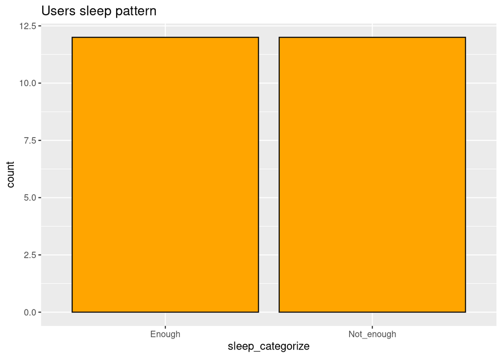

```r
 less_sleep <- Id_sleep_stats %>%
                 filter( sleep < 420)

 less_time_in_bed <- less_sleep %>%
                 filter(time_in_bed < 420)

 sleep_categorized <- Id_sleep_stats %>%
   mutate( sleep_categorize = ifelse(sleep > 420, "Enough", "Not_enough"))

 sleep_pattern <- sleep_categorized %>%
         group_by(sleep_categorize) %>%
         summarise( count = n())

  ggplot(data = sleep_pattern, aes(x = sleep_categorize, y = count))+
 geom_bar( stat = "identity",fill = "orange", color = "black") +
 ggtitle("Users sleep pattern")
```

- Half of the Users are not getting enough sleep.

Analysis on time spent in bed by users

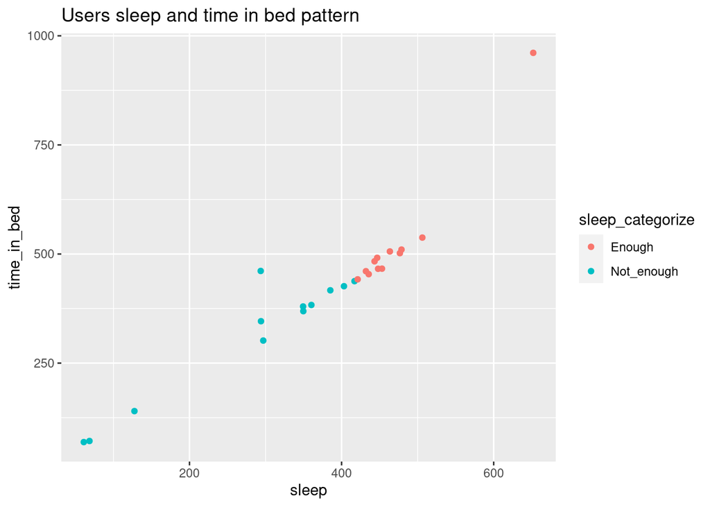

```r
  ggplot(data = sleep_categorized, aes(x = sleep, y = time_in_bed, color = sleep_categorize ))+
 geom_point( ) +
 ggtitle("Users sleep and time in bed pattern")
```

*increased time in bed leads to enough sleep

#### 3.4 USERS ACTIVE AND SEDENTARY MINUTES

*Analysis on users active and sedentary minutes.* Users with more sedentary minutes than the average.

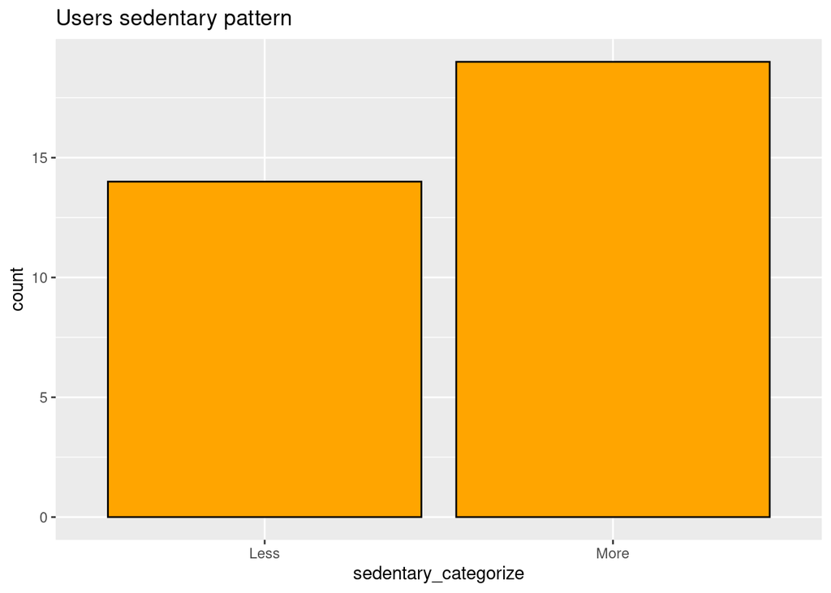

```r
  more_sedentary <- Id_stats_daily %>%
    filter( sedentary > active)

  sedentary_categorized <- Id_stats_daily %>%
    mutate( sedentary_categorize = ifelse(sedentary > 991, "More", "Less"))

  sedentary_pattern <- sedentary_categorized %>%
    group_by(sedentary_categorize) %>%
    summarise( count = n())

    ggplot(data = sedentary_pattern, aes(x = sedentary_categorize, y = count)) +
    geom_bar( stat = "identity",fill = "orange", color = "black")+
    ggtitle("Users sedentary pattern")
```

*More Users are having higher sedentary minutes than the average

#### 3.5 USERS STEPS

Analysis to comparing the users steps and get details for users with more sedentary minutes than the average

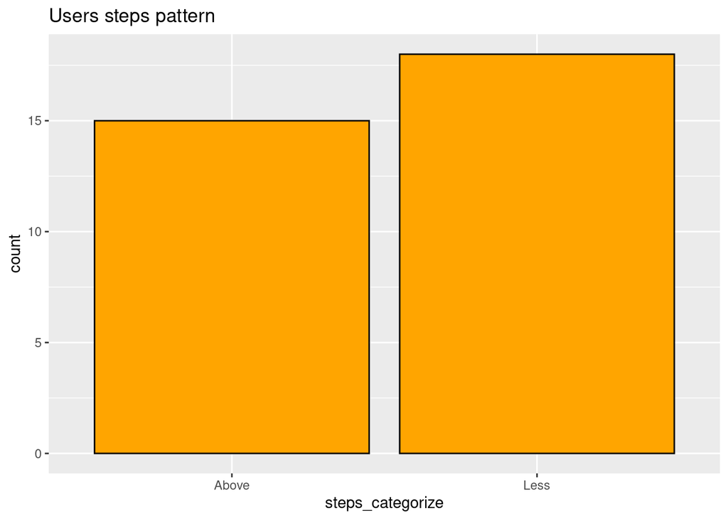

```r
  steps_categorized <- Id_stats_daily %>%
    mutate( steps_categorize = ifelse(steps > 7637, "Above", "Less"))

  steps_pattern <- steps_categorized %>%
    group_by(steps_categorize) %>%
    summarise( count = n())

 ggplot(data = steps_pattern, aes(x = steps_categorize, y = count)) +
 geom_bar( stat = "identity",fill = "orange", color = "black") +
    ggtitle("Users steps pattern")
```

*18 (54%) users have less steps than the average

#### 3.6 USERS DAILY STATISTICS TRENDS

Analysis on the trends for different users metrics: calories, steps, sedentary minutes and active minutes

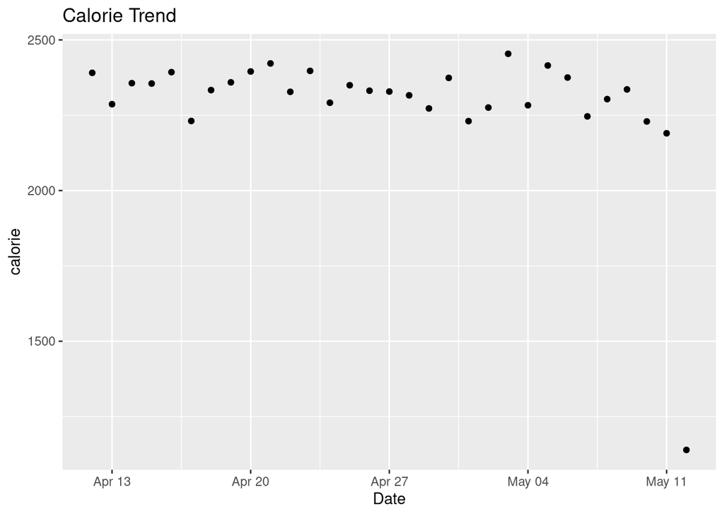

```r
  # Trend
  Id_stats_date <- daily%>%
    group_by(Date) %>%
    summarize(steps = mean(TotalSteps), calorie = mean(Calories),
              sedentary = mean(SedentaryMinutes), active = mean(VeryActiveMinutes))

  ggplot(data = Id_stats_date,aes(x = Date, y = calorie)) +
    geom_point() +
    ggtitle("Calorie Trend")
```

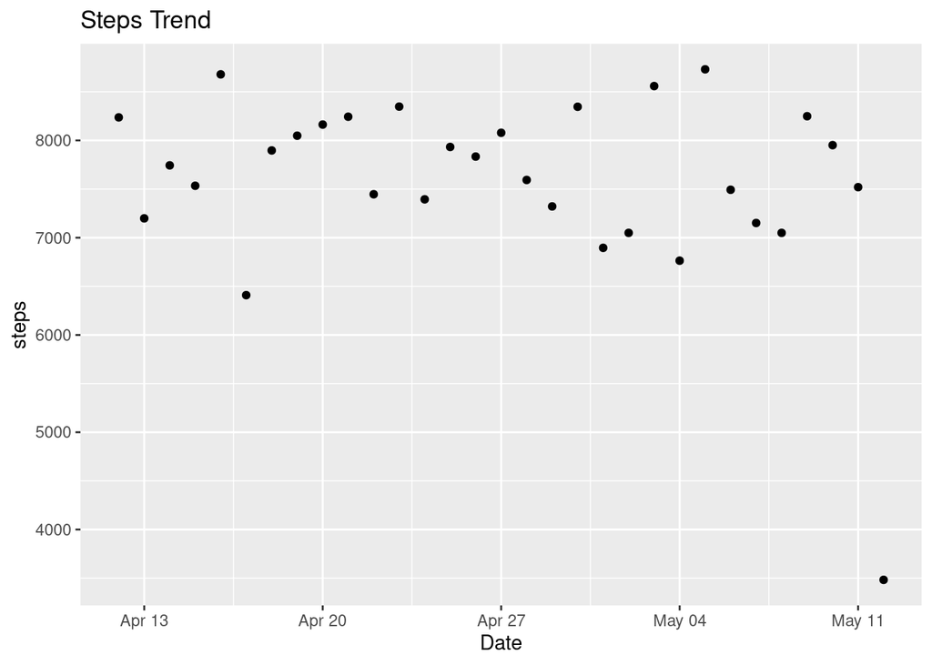

```r
  ggplot(data = Id_stats_date,aes(x = Date, y = steps)) +
    geom_point() +
    ggtitle("Steps Trend")
```

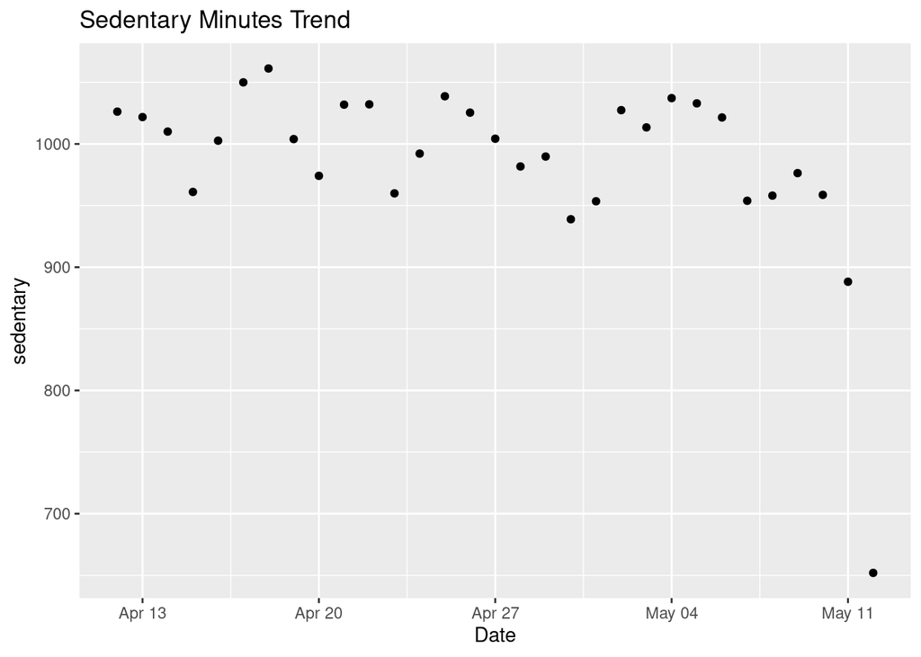

```r
  ggplot(data = Id_stats_date,aes(x = Date, y = sedentary)) +
    geom_point() +
    ggtitle("Sedentary Minutes Trend")
```

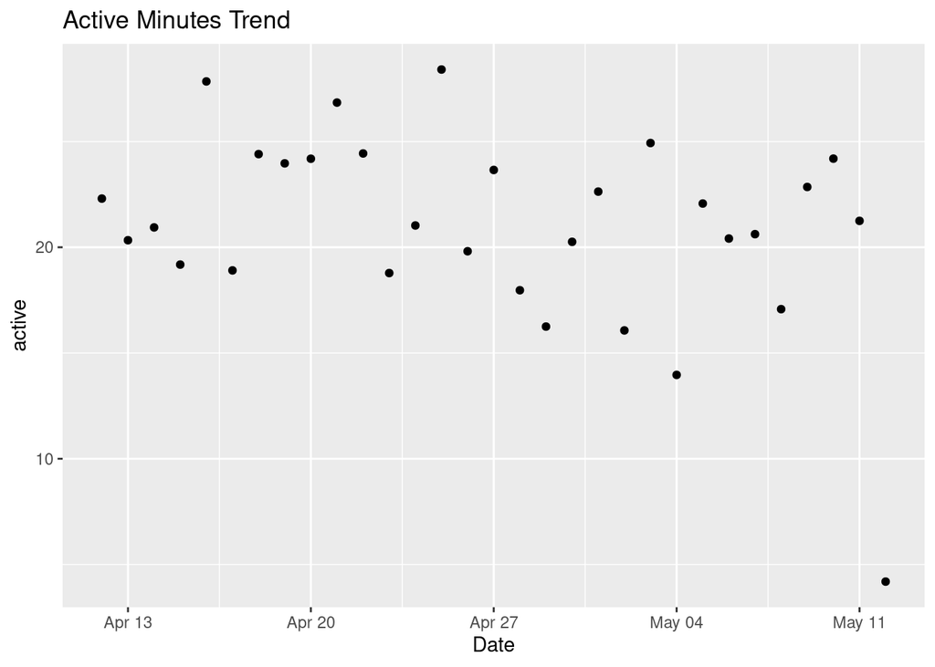

```r
    ggplot(data = Id_stats_date,aes(x = Date, y = active)) +
    geom_point() +
    ggtitle("Active Minutes Trend")
```

Users sleep and time in bed trend

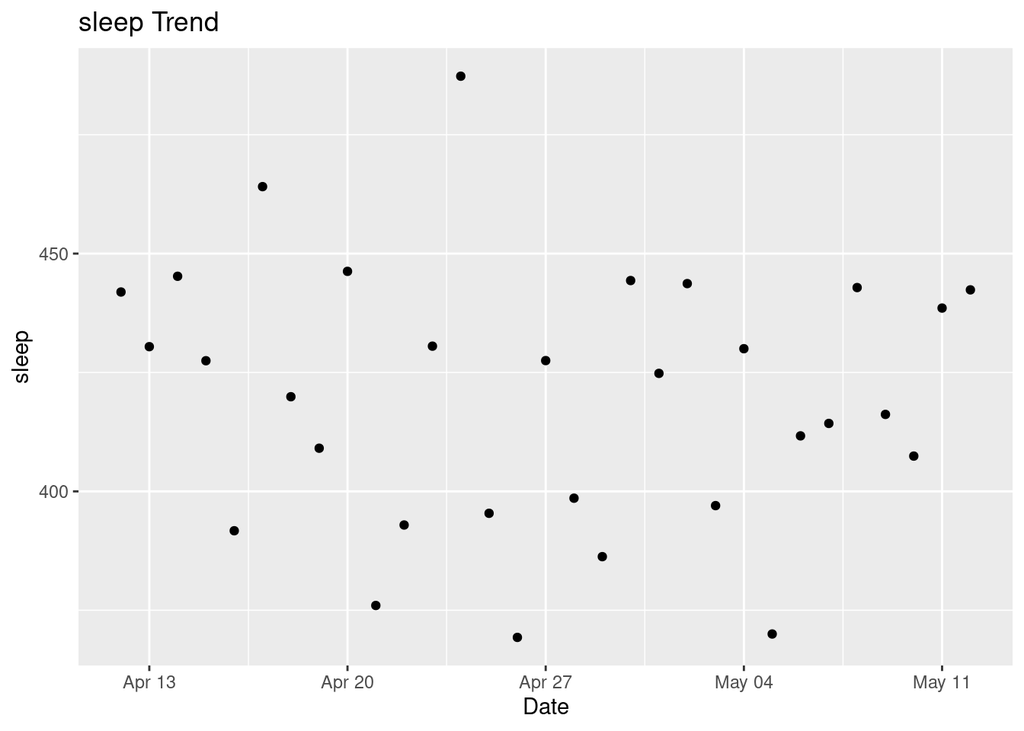

```r
  Id_sleep_date <- sleep%>%
    group_by(Date) %>%
    summarize(sleep = mean(TotalMinutesAsleep), time_in_bed = mean(TotalTimeInBed))

  ggplot(data = Id_sleep_date,aes(x = Date, y = sleep)) +
    geom_point() +
    ggtitle("sleep Trend")
```

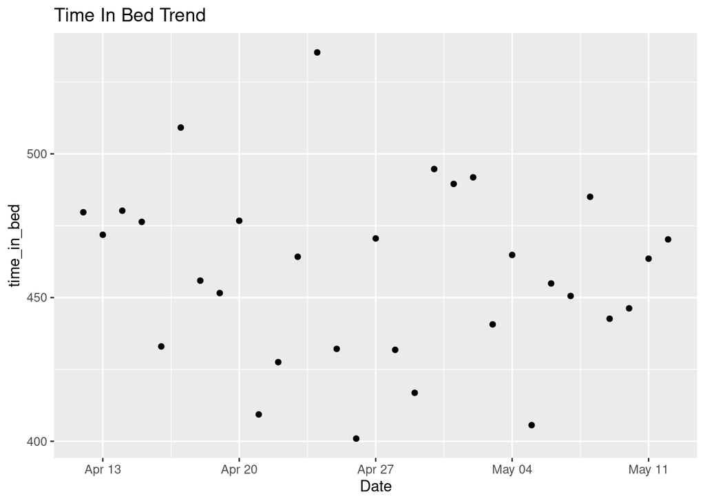

```r
  ggplot(data = Id_sleep_date,aes(x = Date, y = time_in_bed)) +
    geom_point() +
    ggtitle("Time In Bed Trend")
```

#### 3.7 USERS STATISTICS ON DIFFERENT DAYS

Analysis on users daily metris on weekdays . We categorize date into week days and analyze users steps, calories, sedentary minutes and active minutes on different days

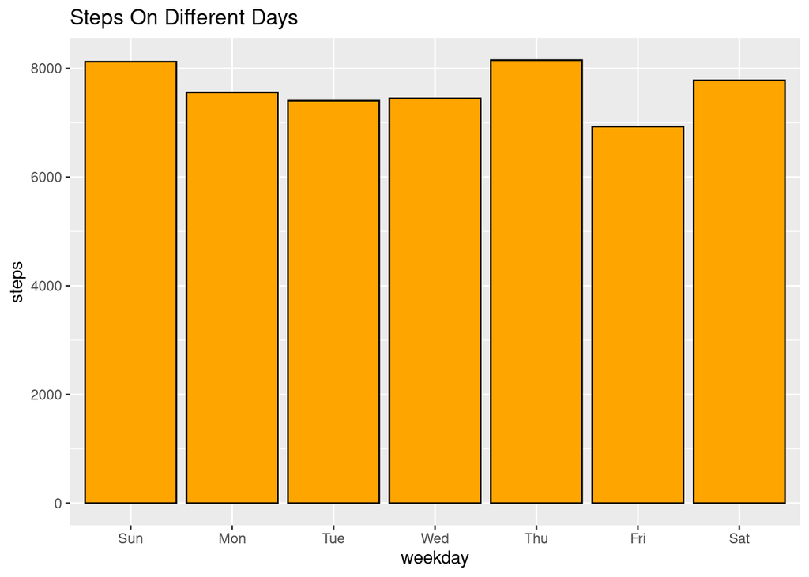

```r
  weekday_daily <- daily %>%
               mutate( weekday = wday(Date, label = TRUE)) %>%
               group_by(weekday) %>%
               summarize(steps = mean(TotalSteps), calorie = mean(Calories),
               sedentary = mean(SedentaryMinutes), active = mean(VeryActiveMinutes),)

  ggplot(data = weekday_daily,aes(x = weekday, y = steps)) +
    geom_bar( stat = "identity",fill = "orange", color = "black")+
    ggtitle("Steps On Different Days")
```

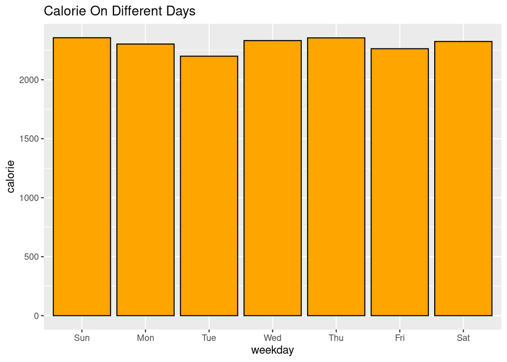

```r
  ggplot(data = weekday_daily,aes(x = weekday, y = calorie)) +
    geom_bar( stat = "identity",fill = "orange", color = "black")+
    ggtitle("Calorie On Different Days")
```

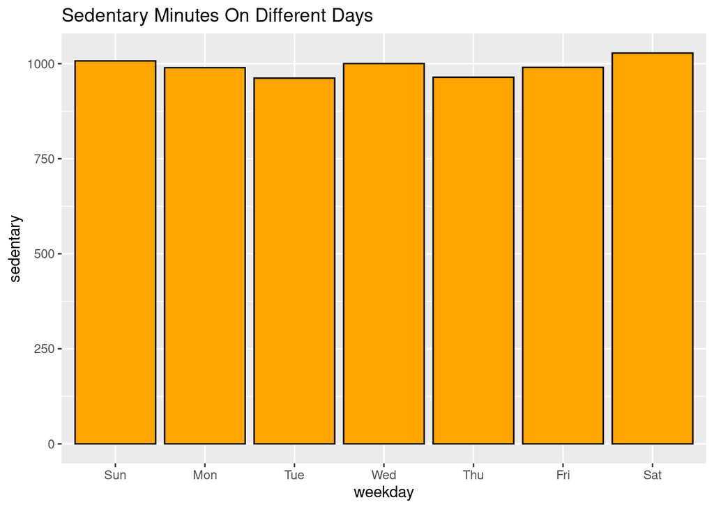

```r
    ggplot(data = weekday_daily,aes(x = weekday, y = sedentary)) +
    geom_bar( stat = "identity",fill = "orange", color = "black")+
    ggtitle("Sedentary Minutes On Different Days")
```

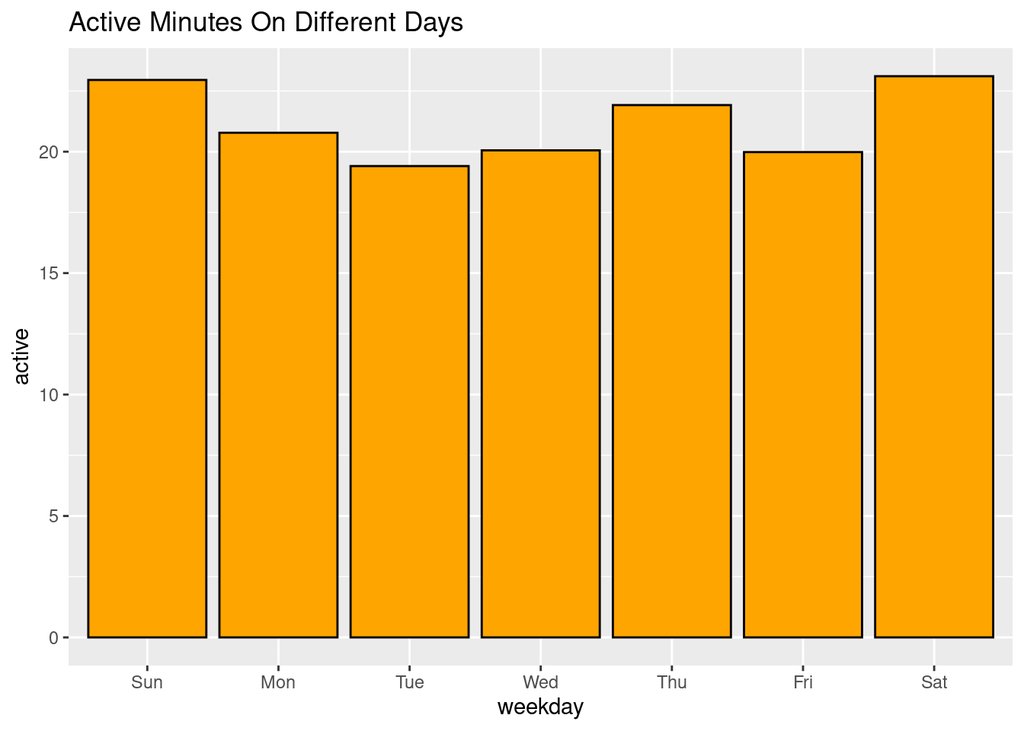

```r
  ggplot(data = weekday_daily,aes(x = weekday, y = active)) +
    geom_bar( stat = "identity",fill = "orange", color = "black")+
    ggtitle("Active Minutes On Different Days")
```

```r
   # more active on weekends

  weekday_sleep <- sleep %>%
    mutate( weekday = wday(Date, label = TRUE)) %>%
    group_by(weekday) %>%
    summarize(sleep = mean(TotalMinutesAsleep), time_in_bed = mean(TotalTimeInBed))
```

*Users are more active on weekends than on week days

sleep minutes and time in bed on different days.

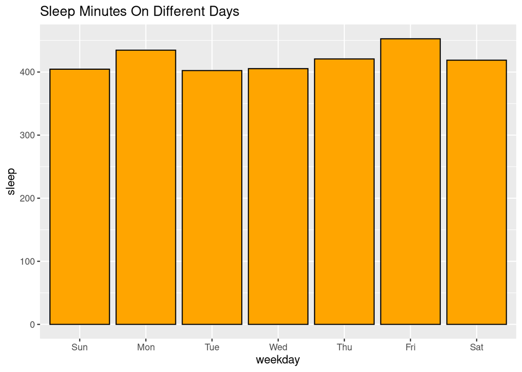

```r
  weekday_sleep <- sleep %>%
    mutate( weekday = wday(Date, label = TRUE)) %>%
    group_by(weekday) %>%
    summarize(sleep = mean(TotalMinutesAsleep), time_in_bed = mean(TotalTimeInBed))

  ggplot(data = weekday_sleep,aes(x = weekday, y = sleep)) +
    geom_bar( stat = "identity",fill = "orange", color = "black")+
    ggtitle("Sleep Minutes On Different Days")
```

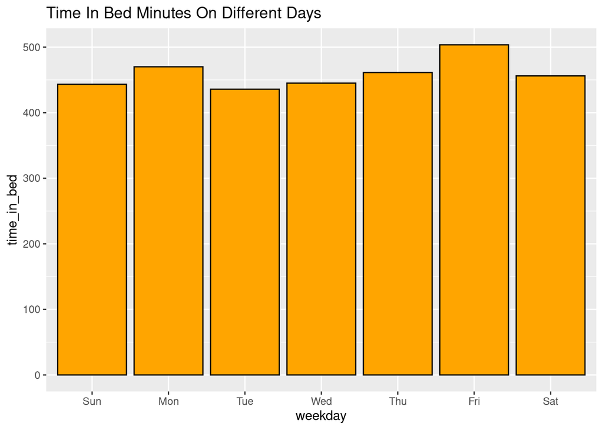

```r
  # more sleep on weekends

  ggplot(data = weekday_sleep,aes(x = weekday, y = time_in_bed)) +
    geom_bar( stat = "identity",fill = "orange", color = "black")+
    ggtitle("Time In Bed Minutes On Different Days")
```

#### 3.8 USERS METRICS ON WEEKENDS AND WEEK DAYS

Analysis on users steps, calories, sedentary minutes and active minutes metrics on weekends and week days.

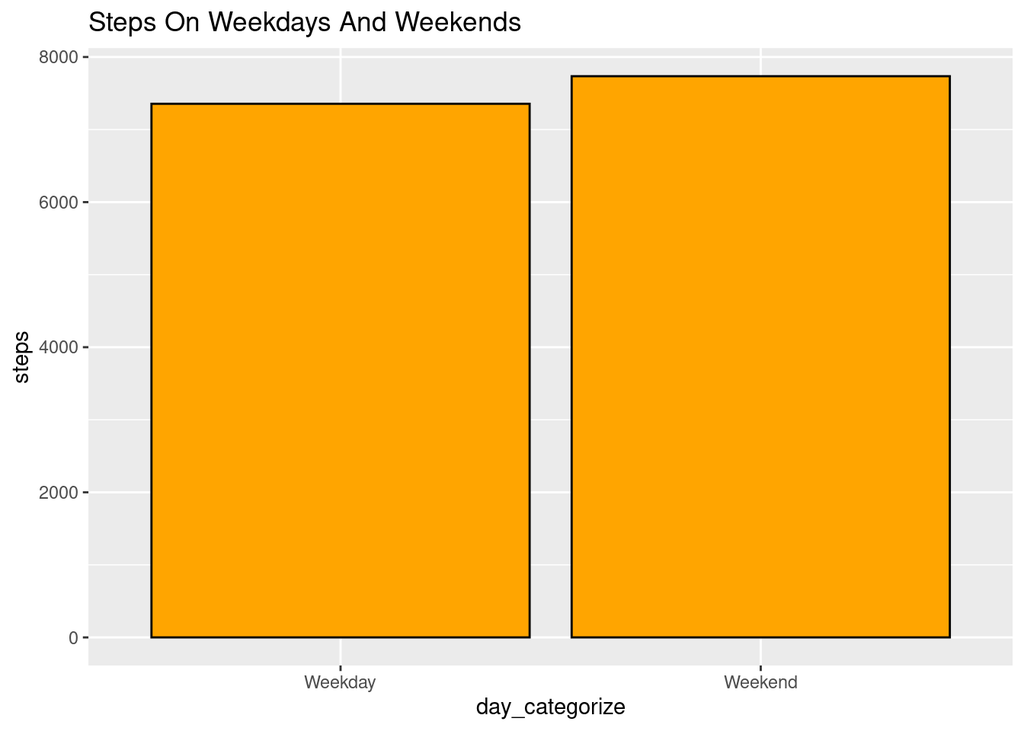

```r
  week_daily <- daily %>%
    mutate( day = wday(Date)) %>%
    mutate( day_categorize = ifelse(day == 6| day == 7, "Weekday", "Weekend")) %>%
    group_by(day_categorize) %>%
    summarize(steps = mean(TotalSteps), calorie = mean(Calories),
              sedentary = mean(SedentaryMinutes), active = mean(VeryActiveMinutes),)

  ggplot(data = week_daily,aes(x = day_categorize, y = steps)) +
    geom_bar( stat = "identity",fill = "orange", color = "black")+
    ggtitle("Steps On Weekdays And Weekends")
```

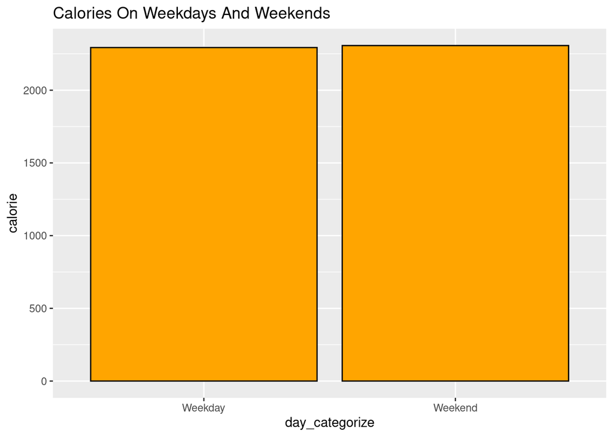

```r
  ggplot(data = week_daily,aes(x = day_categorize, y = calorie)) +
    geom_bar( stat = "identity",fill = "orange", color = "black")+
    ggtitle("Calories On Weekdays And Weekends")
```

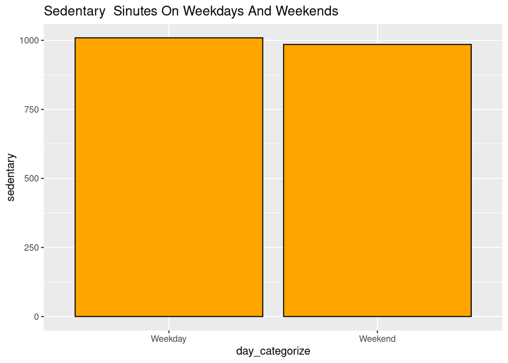

```r
  ggplot(data = week_daily,aes(x = day_categorize, y = sedentary))+
    geom_bar( stat = "identity",fill = "orange", color = "black")+
    ggtitle("Sedentary  Sinutes On Weekdays And Weekends")
```

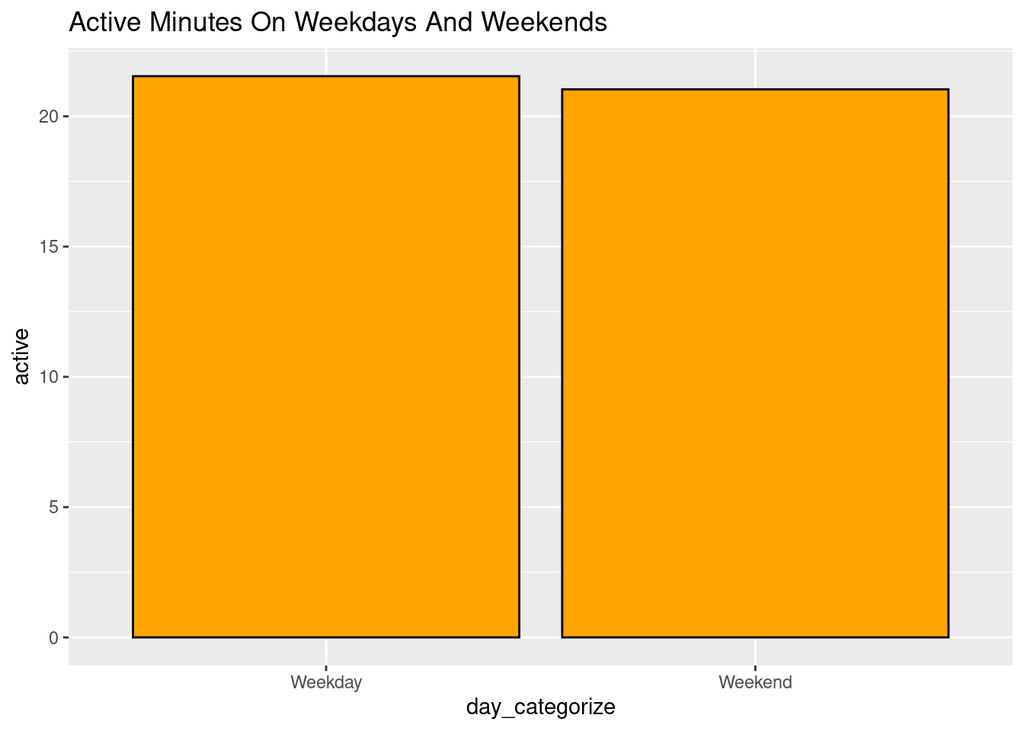

```r
  ggplot(data = week_daily,aes(x = day_categorize, y = active)) +
    geom_bar( stat = "identity",fill = "orange", color = "black")+
    ggtitle("Active Minutes On Weekdays And Weekends")
```

We will categorize users sleep on weekends and week days and time in bed minutes on weekdays and weekend

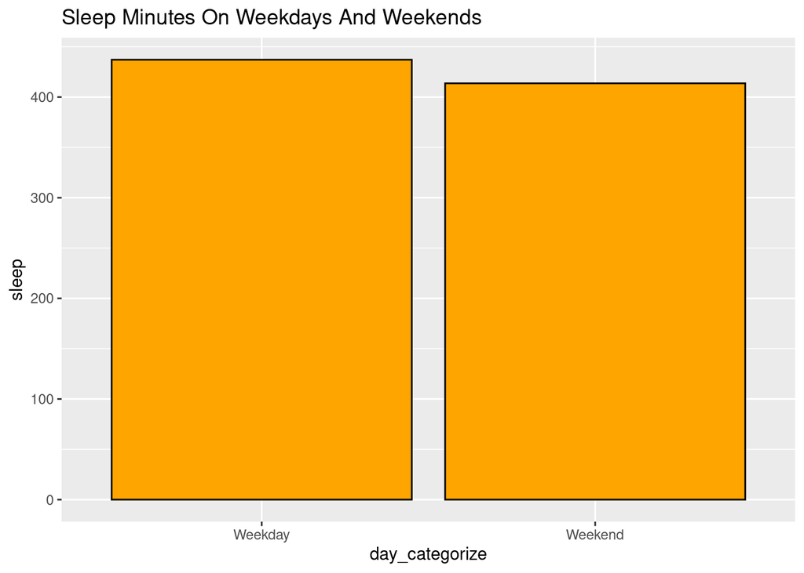

```r
  week_sleep <- sleep %>%
    mutate( day = wday(Date)) %>%
    mutate( day_categorize = ifelse(day == 6| day == 7, "Weekday", "Weekend")) %>%
    group_by(day_categorize) %>%
    summarize(sleep = mean(TotalMinutesAsleep), time_in_bed = mean(TotalTimeInBed))


  ggplot(data = week_sleep,aes(x = day_categorize, y = sleep)) +
    geom_bar( stat = "identity",fill = "orange", color = "black")+
    ggtitle("Sleep Minutes On Weekdays And Weekends")
```

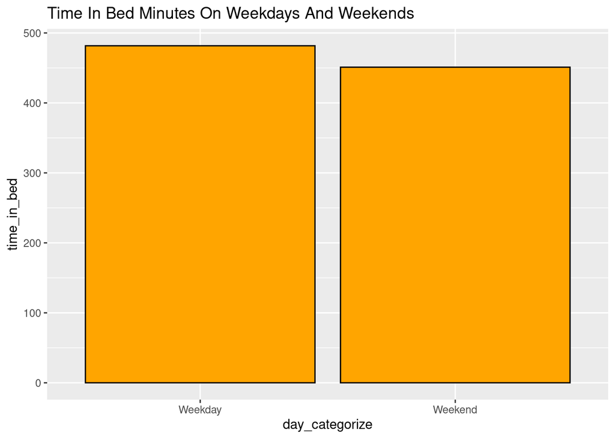

```r
  ggplot(data = week_sleep,aes(x = day_categorize, y = time_in_bed)) +
    geom_bar( stat = "identity",fill = "orange", color = "black")+
    ggtitle("Time In Bed Minutes On Weekdays And Weekends")
```

#### 3.9 USERS PERFORMANCE

We categorizing users into top, average and worse performers using the different metrics averages. * for active minutes 21 is the average metrice score, * for sedentary minutes 991 is the average metrice score, * for steps 7637 is the average metrice score,

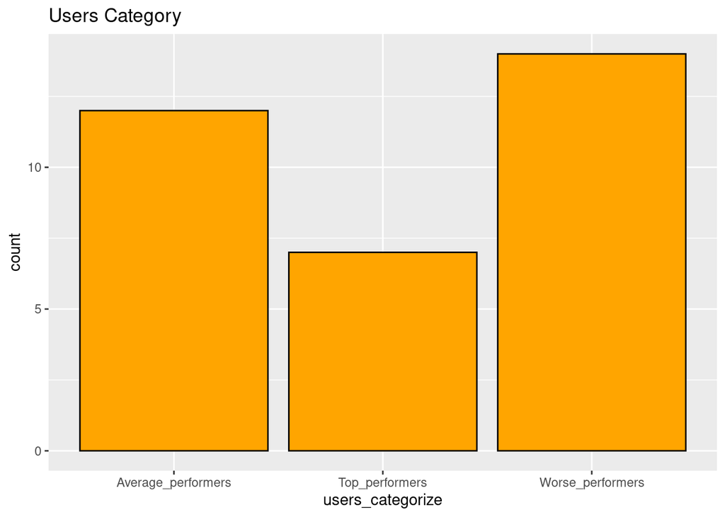

```r
  top_performers <- Id_stats_daily %>%
            filter( active > 21 &sedentary < 991 & steps > 7637)

  worse_performers <- Id_stats_daily %>%
    filter( active < 21 &sedentary > 991 & steps < 7637)

  users_categorized <- Id_stats_daily %>%
    mutate(users_categorize =
             ifelse(( active > 21 &sedentary < 991 & steps > 7637), "Top_performers",
             ifelse(( active < 21 &sedentary > 991 & steps < 7637), "Worse_performers","Average_performers" )))

  users_categories <- users_categorized %>%
                       group_by(users_categorize) %>%
                       summarise( count = n())
  ggplot(data = users_categories,aes(x = users_categorize, y = count)) +
  geom_bar( stat = "identity",fill = "orange", color = "black") +
    ggtitle("Users Category")
```